[figure not shown]

# O que é uma API?

- **API** - *Application Programming Interface* (Interface de Programação de Aplicativos): é um serviço que permite que você envie/receba informações de algum servidor na web.
- A arquitetura da **API** geralmente é explicada em termos de *cliente* e *servidor*. A aplicação que envia a solicitação é chamada de *cliente* e a aplicação que envia a resposta é chamada de *servidor*;

# O que é uma API?

- Existem quatro maneiras diferentes pelas quais as APIs podem funcionar, dependendo de quando e por que elas foram criadas: APIs RPC e APIs SOAP, APIs REST, API's WebSocket;
- **APIs RPC**: São conhecidas como *Remote Procedure Calls* (Chamadas de Procedimento Remoto). O cliente conclui uma função (ou um procedimento) no servidor e o servidor envia a saída de volta ao cliente;
- **APIs SOAP**: Usam o *Simple Object Access Protocol* (Protocolo de Acesso a Objetos Simples). Cliente e servidor trocam mensagens usando XML. Esta é uma **API** menos flexível que era mais popular no passado;

# O que é uma API?

- **APIs REST**: *Representational State Transfer* (Transferência Representacional de Estado). São as **API's** mais populares e flexíveis encontradas na Web atualmente. O cliente envia solicitações ao servidor como dados. O servidor usa essa entrada do cliente para iniciar funções internas e retorna os dados de saída ao cliente;
- **API's WebSocket**: é outro desenvolvimento de **API** da Web moderno que usa objetos `JSON` para passar dados. Uma *API WebSocket* oferece suporte à comunicação bidirecional entre aplicativos cliente e o servidor. O servidor pode enviar mensagens de retorno de chamada a clientes conectados, tornando-o mais eficiente que a *API REST*;

# API REST

- A principal característica da **API REST** é a ausência de estado, i.e. os servidores não salvam dados do cliente entre as solicitações. As solicitações do cliente ao servidor são semelhantes aos *URLs* que você digita no navegador para visitar um site. A resposta do servidor corresponde a dados simples, dessa forma clientes e servidores trocam dados usando HTTP;
- Seu serviço vai prover uma *URL* base e os métodos HTTP vão indicar qual ação está sendo requisitada pelo consumidor do serviço. Alguns métodos HTML são: `GET`, `PUT`, `POST`, `PATCH`, `DELETE` e assim por diante. Os mesmos são usados pelos clientes para acessar os dados do servidor.

## API REST - Um exemplo

Considere a URL: `www.notasdocurso.com/topicos/notas`. Imagine que envia uma requisição HTTP utilizando o verbo `GET`. Certamente obterá como resultado uma listagem de registros das notas do curso.

Por outro lado, se você envia uma requisição HTTP utilizando o verbo `POST`, provavelmente a sua intenção é adicionar uma novo registro de notas. Já o verbo `DELETE` indicaria que desejamos remover um registro, o `PUT` utilizado para criar ou editar um recurso e assim por diante.

Cada método HTTP executa uma certa ação durante a requisição.

# Padrões de resposta do serviço

- O serviço pode retornar o resultado em diversos formatos – `JSON`, `XML`, texto plano, etc. Contudo, atualmente o formato mais adotado tem sido o `JSON`, por seu formato leve, legível e sua fácil interpretação por diversas tecnologias;
- Os objetos `JSON` (*JavaScript Object Notation*) são bem parecidos com os dicionários do **Python**, o que facilita a interpretação das suas representações de `strings`;

```python
# Exemplo da sintaxe de um arquivo JSON

{"id":3354,
"uid":"bab688fe-6a85-4f02-aa82-a82c0fd6f431",
"number":9959123954,
"leading_zero_number":"0353967306",
"decimal":80.97,
"normal":50.370354669799134,
"hexadecimal":"25adca0eb5a59026",
"positive":2851.2589170814235,
"negative":-621.4658395653969,
"non_zero_number":2,
"digit":5}
```

# API REST

[figure not shown]

## Códigos do resultado do processamento

- O protocolo HTTP dispõe de diversos códigos (ou status) que devem ser incluídos na resposta, indicando o resultado do processamento:
  - Os códigos iniciados em **2** indicam que a operação foi bem **sucedida**. Nessa categoria temos, por exemplo:
    - **código 200 (OK)**: iniciando que o método foi executado com sucesso;
    - **código 201 (Created)**: indicando que um novo recurso foi criado no servidor; e
    - **código 204 (No Content)**: quando a requisição foi bem sucedida, mas o servidor não precisa retornar nenhum conteúdo para o cliente.

## Códigos do resultado do processamento

- ...
  - Já os códigos iniciados em **4** indicam algum erro que provavelmente partiu do cliente. Por exemplo:
    - **código 400 (Bad Request)**: indica que a requisição não pôde ser compreendida pelo servidor;
    - **código 404 (Not Found)**: indica que o recurso não foi localizado.
  - Há, ainda, os códigos que indicam erro do lado do servidor. Nesse caso, eles iniciam com **5**, como o 500 (Internal Server Error), que indica que ocorreu um erro internamente no servidor que o impediu de processar e responder adequdamente a requisição.

## Códigos do resultado do processamento

```python
import IPython.display as ip
ip.IFrame('https://www.w3.org/Protocols/rfc2616/rfc2616-sec10.html', width='100%', height=650)
```

[interactive chart not shown]

### Quais são os diferentes tipos de API?

As APIs são classificadas de acordo com sua arquitetura e escopo de uso. Enquanto ao escopo de uso temos:

- **API's públicas**: Estas são abertas ao público e podem ser usadas por qualquer pessoa. Pode ou não haver alguma autorização e custo associado a esses tipos de **API's**. Mesmo sendo pública, os dados podem estar sobre proteção de alguma licença (Creative commons, Apache, MIT, etc.). Dessa forma, ao consumir uma **API** siga todas as normas especificadas pela licença;
- **API's privadas**: Elas são internos a uma empresa e são usadas apenas para conectar sistemas e dados dentro da empresa;

### Quais são os diferentes tipos de API?

- **API's de parceiros**: Estas são acessíveis apenas por desenvolvedores externos autorizados para auxiliar as parcerias entre empresas;
- **API's compostas**: Estas combinam duas ou mais **API's** distintas para atender a requisitos ou comportamentos complexos do sistema.

# Acesso a uma API REST

Todas as APIs devem sãor protegidas por meio de autenticação e monitoramento adequados. As duas principais maneiras de proteger **API's REST** são:

- **Tokens de autenticação**: Eles são usados para autorizar os usuários a fazer a chamada de **API**. Os tokens de autenticação verificam a veracidade dos usuários e se eles têm direitos de acesso para aquela chamada de **API** específica. Por exemplo, quando você faz login para revisar seu e-mail, seu cliente de e-mail usa tokens de autenticação para um acesso seguro;
- **Chaves de API**: As chaves de **API** verificam o programa ou a aplicação que faz a chamada de **API**. Elas identificam a aplicação e garantem que ela tenha os direitos de acesso necessários para fazer a chamada de **API** específica. As chaves de API não são tão seguras quanto os tokens, mas permitem o monitoramento da **API** para coletar dados.

### Onde posso encontrar novas API's?

- https://rapidapi.com/: Nesse site você pode encontrar mais de 10.000 **API's** públicas e 1 milhão de desenvolvedores ativos no local. As categorias disponíveis (free) encontram-se [aqui](https://rapidapi.com/collection/list-of-free-apis);
- [Public APIs](https://github.com/public-apis/public-apis): a plataforma agrupa **API's** em 40 categorias, tornando mais fácil navegar e encontrar a **API** certa para atender às suas necessidades;
- https://apilist.fun/: O site oferece mais de 500 **API's** Web, juntamente com informações detalhadas sobre como usá-las;
- [Public REST APIs](https://documenter.getpostman.com/view/8854915/Szf7znEe): Esta é uma coleção de diferentes **API's REST** que são completamente públicas e não requerem nenhuma autenticação, tornando mais fácil para os usuários brincar e entender o que são as **API's**, vendo as muitas maneiras diferentes pelas quais as **API's** podem ser usadas;
- Mais **API's** na seção de [Datasets](https://bit.ly/3xKx6LV);

# Alguns exemplos

# Consumindo uma API

Nesse primeiro exemplo trabalharemos com um gerador de dados do site https://random-data-api.com/documentation.

De acordo com o site, o parâmetros para considerar são:

- **URL**: https://random-data-api.com/api/;
- `size=number`: para indicar a quantidade de dados requisitados (máx=100);
- `is_xml=true`: para retornar os dados em formato `XML`;

**Exemplo:** https://random-data-api.com/api/vehicle/random_vehicle?size=100.

# Consumindo uma API

```python
from urllib.request import urlopen
import json

url = "https://random-data-api.com/api/vehicle/random_vehicle?size=100"

response = urlopen(url) # Retorna um objeto HTTPResponse

print(response)
```

```
<http.client.HTTPResponse object at 0x7fbf4b0ff130>
```

# Consumindo uma API

```python
print(response.read()) # Usamos o método read para fazer a leitura dos dados.
```

```
b'[{"id":4025,"uid":"f83c52c2-0382-46f3-8739-28521268951e","vin":"A9EZ1UAJ7RJH67750","make_and_model":"Buick Encore","color":"Violet","transmission":"CVT","drive_type":"FWD","fuel_type":"Gasoline Hybrid","car_type":"Regular Cab Pickup","car_options":["AM/FM Stereo","Premium Sound","CD (Single Disc)"…
```

# Consumindo uma API

```python
from urllib.request import urlopen
import json

url = "https://random-data-api.com/api/vehicle/random_vehicle?size=100"

response = urlopen(url) # Retorna um objeto HTTPResponse

dados = json.loads(response.read())  # Usamos o json.loads para fazer a conversão a JSON
print(dados)
```

```
[{'id': 3312, 'uid': 'ce007285-8aff-4307-88df-f6b56614d505', 'vin': '76VM3C67FPR848756', 'make_and_model': 'Ford Fiesta', 'color': 'White', 'transmission': 'CVT', 'drive_type': 'RWD', 'fuel_type': 'Diesel', 'car_type': 'Convertible', 'car_options': ['Leather Interior', 'MP3 (Single Disc)', 'Keyless …
```

# Consumindo uma API

```python
from urllib.request import urlopen
import json
from pprint import pprint

url = "https://random-data-api.com/api/vehicle/random_vehicle?size=100"

response = urlopen(url) # Retorna um objeto HTTPResponse

dados = json.loads(response.read())  # Usamos o json.loads para fazer a conversão a JSON
pprint(dados)
```

```
[{'car_options': ['Antilock Brakes',
                  'AM/FM Stereo',
                  'Antilock Brakes',
                  'Alarm',
                  'Cassette Player',
                  'AM/FM Stereo',
                  'Cruise Control',
                  'Bucket Seats'],
  'car_type': 'Convertible',
  'color': 'Beige',
  'doors': 4,
  'drive_type': 'AWD',
  'fuel_type': 'Ethanol',
  'id': 7567,
  'kilometrage': 34828,
  'license_plate': 'TPR-5627',
  'make_and_model': 'Lincoln MKS',
  'mileage': 86856,
  'specs': ['Body color sill extension',
            '60/40 folding rear seat',
            'Front wheel drive',
            'Dual front knee airbags',
            'Run flat tires'],
  'transmission': 'Manual',
  'uid': 'd3a2c2b6-717c-4899-8024-26f121effb30',
  'vin': '91HDM85O95B939054'},
 {'car_options': ['Airbag: Passenger',
                  'Leather Interior',
                  'Fog Lights',
                  'CD (Multi Disc)',
                  'AM/FM Stereo',
                  'A/C: Rear'],
  'car_type': 'Cargo Van',
  'color': 'Violet',
  'doors': 1,
  'drive_type': 'AWD',
  'fuel_type': 'E-85/Gasoline',
  'id': 4539,
  'kilometrage': 75651,
  'license_plate': 'DTU-8794',
```

[output cut: 2706 more lines]

```
  'license_plate': 'LZF-3620',
  'make_and_model': 'Chevy Silverado',
  'mileage': 10820,
  'specs': ['Dual-zone automatic climate control system -inc: smog sensor, '
            'auto recirculation, clear air filter, pollen filter',
            '160-amp alternator',
            'Acoustic control induction system (ACIS)',
            'Highline door trim panel',
            'High performance suspension',
            'Body color front license plate brow',
            'Anti-lock brake system (ABS) -inc: electronic brake force '
            'distribution (EBD), brake assist'],
  'transmission': 'Automatic',
  'uid': '7cd22e0b-9cc4-4e6e-b221-417db7a118dd',
  'vin': '517I7914UG0156713'}]
```

# Consumindo uma API

```python
pprint(dados[0])
```

```
{'car_options': ['Antilock Brakes',
                 'AM/FM Stereo',
                 'Antilock Brakes',
                 'Alarm',
                 'Cassette Player',
                 'AM/FM Stereo',
                 'Cruise Control',
                 'Bucket Seats'],
 'car_type': 'Convertible',
 'color': 'Beige',
 'doors': 4,
 'drive_type': 'AWD',
 'fuel_type': 'Ethanol',
 'id': 7567,
 'kilometrage': 34828,
 'license_plate': 'TPR-5627',
 'make_and_model': 'Lincoln MKS',
 'mileage': 86856,
 'specs': ['Body color sill extension',
           '60/40 folding rear seat',
           'Front wheel drive',
           'Dual front knee airbags',
           'Run flat tires'],
 'transmission': 'Manual',
 'uid': 'd3a2c2b6-717c-4899-8024-26f121effb30',
 'vin': '91HDM85O95B939054'}
```

# Consumindo uma API

```python
print([i['color'] for i in dados if i['color']]) # Mostrando a lista de cores
```

```
['Beige', 'Violet', 'Orange', 'Black', 'Black', 'Beige', 'Grey', 'White', 'Green', 'Black', 'Yellow', 'Black', 'Yellow', 'Red', 'Red', 'Green', 'White', 'Red', 'Green', 'Orange', 'Yellow', 'Orange', 'Yellow', 'Beige', 'Yellow', 'Red', 'Blue', 'Black', 'Blue', 'Violet', 'Orange', 'Blue', 'Red', 'Oran…
```

# Consumindo uma API

```python
from collections import Counter

print(*Counter([i['color'] for i in dados if i['color']]))
```

```
Beige Violet Orange Black Grey White Green Yellow Red Blue
```

```python
import numpy as np

print(np.unique([i['color'] for i in dados if i['color']]))
```

```
['Beige' 'Black' 'Blue' 'Green' 'Grey' 'Orange' 'Red' 'Violet' 'White'
 'Yellow']
```

# Consumindo uma API

```python
# Mostrando a lista de opções do carro
lista = [i['car_options'] for i in dados if i['car_options']]
pprint(lista)
```

```
[['Antilock Brakes',
  'AM/FM Stereo',
  'Antilock Brakes',
  'Alarm',
  'Cassette Player',
  'AM/FM Stereo',
  'Cruise Control',
  'Bucket Seats'],
 ['Airbag: Passenger',
  'Leather Interior',
  'Fog Lights',
  'CD (Multi Disc)',
  'AM/FM Stereo',
  'A/C: Rear'],
 ['CD (Multi Disc)',
  'Keyless Entry',
  'Moonroof/Sunroof',
  'A/C: Front',
  'Keyless Entry'],
 ['CD (Multi Disc)',
  'A/C: Front',
  'Airbag: Passenger',
  'A/C: Front',
  'Integrated Phone',
  'MP3 (Single Disc)'],
 ['Cruise Control',
  'Airbag: Driver',
  'Airbag: Passenger',
  'Moonroof/Sunroof',
  'MP3 (Single Disc)',
  'Power Locks',
  'MP3 (Single Disc)'],
 ['Power Windows',
  'Tinted Glass',
  'A/C: Rear',
  'Tow Package',
  'Antilock Brakes',
  'Keyless Entry',
  'Cassette Player'],
 ['Cruise Control',
```

[output cut: 633 more lines]

```
  'Tow Package'],
 ['Memory Seats',
  'Airbag: Side',
  'AM/FM Stereo',
  'A/C: Front',
  'Power Windows',
  'Power Windows',
  'MP3 (Single Disc)',
  'A/C: Rear'],
 ['Tow Package',
  'Tow Package',
  'Antilock Brakes',
  'Cruise Control',
  'Integrated Phone',
  'Cassette Player']]
```

# Consumindo uma API

```python
# Mostrando a lista de opções do carro
lista = [i['car_options'] for i in dados if i['car_options']]
pprint([x for i in lista for x in i])
```

```
['Antilock Brakes',
 'AM/FM Stereo',
 'Antilock Brakes',
 'Alarm',
 'Cassette Player',
 'AM/FM Stereo',
 'Cruise Control',
 'Bucket Seats',
 'Airbag: Passenger',
 'Leather Interior',
 'Fog Lights',
 'CD (Multi Disc)',
 'AM/FM Stereo',
 'A/C: Rear',
 'CD (Multi Disc)',
 'Keyless Entry',
 'Moonroof/Sunroof',
 'A/C: Front',
 'Keyless Entry',
 'CD (Multi Disc)',
 'A/C: Front',
 'Airbag: Passenger',
 'A/C: Front',
 'Integrated Phone',
 'MP3 (Single Disc)',
 'Cruise Control',
 'Airbag: Driver',
 'Airbag: Passenger',
 'Moonroof/Sunroof',
 'MP3 (Single Disc)',
 'Power Locks',
 'MP3 (Single Disc)',
 'Power Windows',
 'Tinted Glass',
 'A/C: Rear',
 'Tow Package',
 'Antilock Brakes',
 'Keyless Entry',
 'Cassette Player',
 'Cruise Control',
```

[output cut: 645 more lines]

```
 'Tow Package',
 'Memory Seats',
 'Airbag: Side',
 'AM/FM Stereo',
 'A/C: Front',
 'Power Windows',
 'Power Windows',
 'MP3 (Single Disc)',
 'A/C: Rear',
 'Tow Package',
 'Tow Package',
 'Antilock Brakes',
 'Cruise Control',
 'Integrated Phone',
 'Cassette Player']
```

# Consumindo uma API

```python
# Mostrando a lista de opções do carro

lista = [i['car_options'] for i in dados if i['car_options']]
print(*Counter([x for i in lista for x in i]))
```

```
Antilock Brakes AM/FM Stereo Alarm Cassette Player Cruise Control Bucket Seats Airbag: Passenger Leather Interior Fog Lights CD (Multi Disc) A/C: Rear Keyless Entry Moonroof/Sunroof A/C: Front Integrated Phone MP3 (Single Disc) Airbag: Driver Power Locks Power Windows Tinted Glass Tow Package Alloy …
```

# Coletando informações do IBGE

# Coletando informações do IBGE

- O primeiro passo para realizar a coleta de dados é saber qual a URL da requisição. No seguinte link você encontrará a documentação de cada **API** diponível no site do IBGE;

```python
ip.IFrame('https://servicodados.ibge.gov.br/api/docs', width='100%', height=650)
```

[interactive chart not shown]

# Coletando informações do IBGE

- Só para ilustrar, vamos coletar os dados correspondentes à frequência dos nomes por década de nascimento;

```python
ip.IFrame('https://servicodados.ibge.gov.br/api/docs/nomes?versao=2', width='100%', height=650)
```

[interactive chart not shown]

# Coletando informações do IBGE

- De acordo com a documentação, o formato de retorno é tipo `JSON`;

```python
[
    {
        "nome": "MARIA",
        "regiao": 0,
        "freq": 11734129,
        "rank": 1,
        "sexo": ""
    },
    {
        "nome": "JOSE",
        "regiao": 0,
        "freq": 5754529,
        "rank": 2,
        "sexo": ""
    },

# ...
]
```

# Coletando informações do IBGE

```python
from urllib.request import urlopen
import json

url = "https://servicodados.ibge.gov.br/api/v2/censos/nomes/"

response = urlopen(url) # Retorna um objeto HTTPResponse

print(response)
```

```
<http.client.HTTPResponse object at 0x7fbf6b010d00>
```

# Coletando informações do IBGE

```python
from urllib.request import urlopen
import json

url = "https://servicodados.ibge.gov.br/api/v2/censos/nomes/"

response = urlopen(url)

print(response.read()) # Usamos o método read para fazer a leitura dos dados.

# Atenção: response.read() mostra uma string e não um JSON!!!
```

```
b'[{"nome":"MARIA","regiao":0,"freq":11734129,"rank":1,"sexo":""},{"nome":"JOSE","regiao":0,"freq":5754529,"rank":2,"sexo":""},{"nome":"ANA","regiao":0,"freq":3089858,"rank":3,"sexo":""},{"nome":"JOAO","regiao":0,"freq":2984119,"rank":4,"sexo":""},{"nome":"ANTONIO","regiao":0,"freq":2576348,"rank":5…
```

# Coletando informações do IBGE

```python
from urllib.request import urlopen
import json

url = "https://servicodados.ibge.gov.br/api/v2/censos/nomes/"

response = urlopen(url)
dados = json.loads(response.read())  # Usamos o json.loads para fazer a conversão a JSON
print(dados)
```

```
[{'nome': 'MARIA', 'regiao': 0, 'freq': 11734129, 'rank': 1, 'sexo': ''}, {'nome': 'JOSE', 'regiao': 0, 'freq': 5754529, 'rank': 2, 'sexo': ''}, {'nome': 'ANA', 'regiao': 0, 'freq': 3089858, 'rank': 3, 'sexo': ''}, {'nome': 'JOAO', 'regiao': 0, 'freq': 2984119, 'rank': 4, 'sexo': ''}, {'nome': 'ANTO…
```

# Coletando informações do IBGE

- Para explorar melhor os dados em formato `JSON` pode usar um visualizar, por exemplo: **[JSON viewer](http://jsonviewer.stack.hu/)**. Dessa forma, copie e cole a saída anterior na janela indicada para texto;

[figure not shown]

# Coletando informações do IBGE

```python
from urllib.request import urlopen
import json

url = "https://servicodados.ibge.gov.br/api/v2/censos/nomes/"

response = urlopen(url)

dados = json.loads(response.read())

pprint(dados[0])      # Mostrando o primeiro registro

for i in dados:      # i é um dicionário!!!
    print(i["nome"], end=" ")
```

```
{'freq': 11734129, 'nome': 'MARIA', 'rank': 1, 'regiao': 0, 'sexo': ''}
MARIA JOSE ANA JOAO ANTONIO FRANCISCO CARLOS PAULO PEDRO LUCAS LUIZ MARCOS LUIS GABRIEL RAFAEL FRANCISCA DANIEL MARCELO BRUNO EDUARDO
```

# Coletando informações do IBGE

```python
from urllib.request import urlopen
import json
from pprint import pprint

# Informando um parâmetro na URL, por exemplo: BRUNO
url = "https://servicodados.ibge.gov.br/api/v2/censos/nomes/bruno"

response = urlopen(url)

dados = json.loads(response.read())

pprint(dados)
```

```
[{'localidade': 'BR',
  'nome': 'BRUNO',
  'res': [{'frequencia': 599, 'periodo': '1930['},
          {'frequencia': 1351, 'periodo': '[1930,1940['},
          {'frequencia': 2071, 'periodo': '[1940,1950['},
          {'frequencia': 2595, 'periodo': '[1950,1960['},
          {'frequencia': 4080, 'periodo': '[1960,1970['},
          {'frequencia': 17911, 'periodo': '[1970,1980['},
          {'frequencia': 172313, 'periodo': '[1980,1990['},
          {'frequencia': 291524, 'periodo': '[1990,2000['},
          {'frequencia': 175773, 'periodo': '[2000,2010['}],
  'sexo': None}]
```

# Coletando informações do IBGE

```python
from urllib.request import urlopen
import json
from pprint import pprint

# Informando um parâmetro na URL
url = "https://servicodados.ibge.gov.br/api/v2/censos/nomes/bruno"

response = urlopen(url)

dados = json.loads(response.read())

pprint(dados[0]["res"][0]) # Primeiro elemento da lista
```

```
{'frequencia': 599, 'periodo': '1930['}
```

# Coletando informações do IBGE

```python
from urllib.request import urlopen
import json
from pprint import pprint

# Informando um parâmetro na URL
url = "https://servicodados.ibge.gov.br/api/v2/censos/nomes/bruno"

response = urlopen(url)

dados = json.loads(response.read())

periodo = [i['periodo'] for i in dados[0]['res']]
freq = [i['frequencia'] for i in dados[0]['res']]
```

# Coletando informações do IBGE

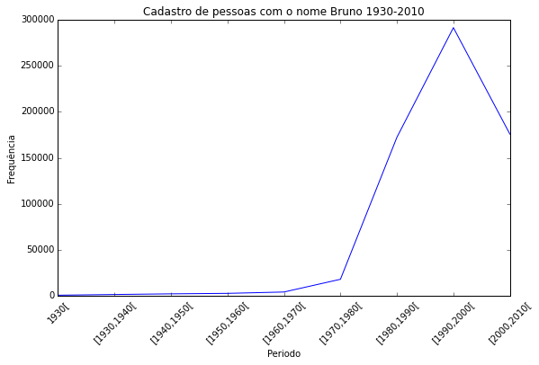

```python
import matplotlib.pyplot as plt
# Mostra a saída na linha
%matplotlib inline
plt.style.use("fast") # Trocando o estilo da figura. Use print(plt.style.available) para outros estilos.
plt.rcParams["figure.figsize"] = (9,5.5) # Aumentando o tamanho da figura
plt.plot(periodo, freq)
plt.xticks(rotation=45)
plt.title("Cadastro de pessoas com o nome Bruno 1930-2010"); plt.xlabel('Periodo'); plt.ylabel('Frequência')
plt.show()
```

# Consumindo API do CEP

## Consumindo API do CEP

```python
# Consumindo API para consultar um CEP
import requests
from pprint import pprint


cep = 29075910

url = f"https://viacep.com.br/ws/{cep}/json/"

response = requests.get(url) # A url responde a petições tipo GET

dados = response.json()

pprint(dados)
```

```
{'bairro': 'Goiabeiras',
 'cep': '29075-910',
 'complemento': '514',
 'ddd': '27',
 'gia': '',
 'ibge': '3205309',
 'localidade': 'Vitória',
 'logradouro': 'Avenida Fernando Ferrari',
 'siafi': '5705',
 'uf': 'ES'}
```

## Consumindo API do CEP

```python
# Consumindo API para consultar um CEP
import requests

cep = input("Digite o CEP (só números): ")

url = f"https://viacep.com.br/ws/{cep}/json/"

response = requests.get(url) # A url responde a petições tipo GET

dados = response.json()

print("\n****** Informações solicitadas******")
print("\nCEP: {0} \nBairro: {1} \nLogradouro: {2}, {3} \nMunicipio: {4}".format(dados['cep'],
                                                                              dados['bairro'],
                                                                              dados['logradouro'],
                                                                              dados['complemento'],
                                                                              dados['localidade']))
```

```
Digite o CEP (só números): 29075910

****** Informações solicitadas******

CEP: 29075-910
Bairro: Goiabeiras
Logradouro: Avenida Fernando Ferrari, 514
Municipio: Vitória
```

# Consumindo API da MARVEL

## Consumindo API da MARVEL

- Primeiramente visitamos o portal de desenvolvedores da Marvel e visitamos a *Documentação Interativa*;

```python
ip.IFrame('https://developer.marvel.com', width='100%', height=650)
```

[interactive chart not shown]

## Consumindo API da MARVEL

- O site mostra a listagem de URL's para realizar as requisições. Mas, para o acesso requere-se uma **chave API** (*API key*). Dessa forma, clicamos na opção **[Get a Ket](https://developer.marvel.com/account)**;

```python
ip.IFrame('https://developer.marvel.com/docs', width='100%', height=650)
```

[interactive chart not shown]

## Consumindo API da MARVEL

- O site solicita acesso à sua conta para gerar a chave. Uma vez criada a sua conta, você receberá um email para confirmação da conta;

[figure not shown]

## Consumindo API da MARVEL

- Uma vez confirmada a conta, volte no site clique em **[here](https://developer.marvel.com/signup)** e aceite os termos e condições. Dessa forma, será disponibilizada uma chave pública (*public key*) e uma chave privada (*private key*);

[figure not shown]

## Consumindo API da MARVEL

- Para consumir a API acessamos as informações diponíveis em *[Read more about how to authorize referring domains in browser-based apps and web sites](https://developer.marvel.com/documentation/authorization)*;

```python
ip.IFrame('https://developer.marvel.com/documentation/authorization', width='100%', height=650)
```

[interactive chart not shown]

## Consumindo API da MARVEL

- De acordo com as informações do site, no item *Authentication for Server-Side Applications* (Autenticação para aplicativos do lado do servidor), precisamos de dois parâmetros: **ts** - *timestamp* (marca de tempo) e um **hash** composto do `ts + privateKey + publicKey` (**ts** + **chave privada** + **chave pública**). Assim, se a chve pública é **1234** e a chave privada é **abcd**, então a requisição é feita como:

`http://gateway.marvel.com/v1/public/comics?ts=1&apikey=1234&hash=ffd275c5130566a2916217b101f26150`;

- Para gerar o md5 podemor usar um gerar online, por exemplo: [MD5 hash generator](https://www.md5hashgenerator.com/);

## Consumindo API da MARVEL

- Seguindo as informações do site, criamos as respectivas variáveis para criação do `hash` e a `url`;

```python
ts = 1
private_key = "8a600f05716fea05219392d6ab4a123c61b77480"
public_key = "700edfff12aa9683c22148f5fa687d5e"

# hash = ts + chave privada + chave pública
# hash = 18a600f05716fea05219392d6ab4a123c61b77480700edfff12aa9683c22148f5fa687d5e

hashed = "1974e9248f16a6758ee3d078d459d32a"

url = f"https://gateway.marvel.com:443/v1/public/characters?ts={ts}&apikey={public_key}&hash={hashed}"
print(url)
```

```
https://gateway.marvel.com:443/v1/public/characters?ts=1&apikey=700edfff12aa9683c22148f5fa687d5e&hash=1974e9248f16a6758ee3d078d459d32a
```

- Para testar se está funcionando a `url` da requisição, pode verifical em [Postman](https://www.postman.com/);

## Consumindo API da MARVEL

```python
import requests
import json
from pprint import pprint

url = f"https://gateway.marvel.com:443/v1/public/characters?ts={ts}&apikey={public_key}&hash={hashed}"
#"https://gateway.marvel.com:443/v1/public/characters?ts=1&apikey=700edfff12aa9683c22148f5fa687d5e&hash=1974e9248f16a6758ee3d078d459d32a"

response = requests.get(url) # A url responde a petições tipo GET

print(response) # Se a resposta é 200, significa que está Ok.
```

```
<Response [200]>
```

## Consumindo API da MARVEL

```python
import requests, json
from pprint import pprint

# Aumentando o limite de resultados para 100
url = url = f"https://gateway.marvel.com:443/v1/public/characters?limit=100&ts={ts}&apikey={public_key}&hash={hashed}"

response = requests.get(url) # A url responde a petições tipo GET

if response.status_code==200:
        dados = json.loads(response.text)
        pprint(dados)
```

```
{'attributionHTML': '<a href="http://marvel.com">Data provided by Marvel. © '
                    '2022 MARVEL</a>',
 'attributionText': 'Data provided by Marvel. © 2022 MARVEL',
 'code': 200,
 'copyright': '© 2022 MARVEL',
 'data': {'count': 100,
          'limit': 100,
          'offset': 0,
          'results': [{'comics': {'available': 12,
                                  'collectionURI': 'http://gateway.marvel.com/v1/public/characters/1011334/comics',
                                  'items': [{'name': 'Avengers: The Initiative '
                                                     '(2007) #14',
                                             'resourceURI': 'http://gateway.marvel.com/v1/public/comics/21366'},
                                            {'name': 'Avengers: The Initiative '
                                                     '(2007) #14 (SPOTLIGHT '
                                                     'VARIANT)',
                                             'resourceURI': 'http://gateway.marvel.com/v1/public/comics/24571'},
                                            {'name': 'Avengers: The Initiative '
                                                     '(2007) #15',
                                             'resourceURI': 'http://gateway.marvel.com/v1/public/comics/21546'},
                                            {'name': 'Avengers: The Initiative '
                                                     '(2007) #16',
                                             'resourceURI': 'http://gateway.marvel.com/v1/public/comics/21741'},
                                            {'name': 'Avengers: The Initiative '
                                                     '(2007) #17',
                                             'resourceURI': 'http://gateway.marvel.com/v1/public/comics/21975'},
                                            {'name': 'Avengers: The Initiative '
                                                     '(2007) #18',
                                             'resourceURI': 'http://gateway.marvel.com/v1/public/comics/22299'},
                                            {'name': 'Avengers: The Initiative '
                                                     '(2007) #18 (ZOMBIE '
                                                     'VARIANT)',
                                             'resourceURI': 'http://gateway.marvel.com/v1/public/comics/22300'},
                                            {'name': 'Avengers: The Initiative '
                                                     '(2007) #19',
                                             'resourceURI': 'http://gateway.marvel.com/v1/public/comics/22506'},
                                            {'name': 'Deadpool (1997) #44',
                                             'resourceURI': 'http://gateway.marvel.com/v1/public/comics/8500'},
                                            {'name': 'Marvel Premiere (1972) '
                                                     '#35',
```

[output cut: 11955 more lines]

```
                                             {'name': 'new x-men 141 cover',
                                              'resourceURI': 'http://gateway.marvel.com/v1/public/stories/67329',
                                              'type': 'cover'}],
                                   'returned': 18},
                       'thumbnail': {'extension': 'jpg',
                                     'path': 'http://i.annihil.us/u/prod/marvel/i/mg/5/90/4c0040b8329ad'},
                       'urls': [{'type': 'detail',
                                 'url': 'http://marvel.com/characters/249/beak?utm_campaign=apiRef&utm_source=700edfff12aa9683c22148f5fa687d5e'},
                                {'type': 'wiki',
                                 'url': 'http://marvel.com/universe/Beak?utm_campaign=apiRef&utm_source=700edfff12aa9683c22148f5fa687d5e'},
                                {'type': 'comiclink',
                                 'url': 'http://marvel.com/comics/characters/1009174/beak?utm_campaign=apiRef&utm_source=700edfff12aa9683c22148f5fa687d5e'}]}],
          'total': 1562},
 'etag': '33366627408af71bf9cf658b1c3f1ddddabcd588',
 'status': 'Ok'}
```

## Consumindo API da MARVEL

```python
# Mostrando a informação do dicionário dados
pprint(dados['data']['results'][0]) # primeiro elemento da lista
```

```
{'comics': {'available': 12,
            'collectionURI': 'http://gateway.marvel.com/v1/public/characters/1011334/comics',
            'items': [{'name': 'Avengers: The Initiative (2007) #14',
                       'resourceURI': 'http://gateway.marvel.com/v1/public/comics/21366'},
                      {'name': 'Avengers: The Initiative (2007) #14 (SPOTLIGHT '
                               'VARIANT)',
                       'resourceURI': 'http://gateway.marvel.com/v1/public/comics/24571'},
                      {'name': 'Avengers: The Initiative (2007) #15',
                       'resourceURI': 'http://gateway.marvel.com/v1/public/comics/21546'},
                      {'name': 'Avengers: The Initiative (2007) #16',
                       'resourceURI': 'http://gateway.marvel.com/v1/public/comics/21741'},
                      {'name': 'Avengers: The Initiative (2007) #17',
                       'resourceURI': 'http://gateway.marvel.com/v1/public/comics/21975'},
                      {'name': 'Avengers: The Initiative (2007) #18',
                       'resourceURI': 'http://gateway.marvel.com/v1/public/comics/22299'},
                      {'name': 'Avengers: The Initiative (2007) #18 (ZOMBIE '
                               'VARIANT)',
                       'resourceURI': 'http://gateway.marvel.com/v1/public/comics/22300'},
                      {'name': 'Avengers: The Initiative (2007) #19',
                       'resourceURI': 'http://gateway.marvel.com/v1/public/comics/22506'},
                      {'name': 'Deadpool (1997) #44',
                       'resourceURI': 'http://gateway.marvel.com/v1/public/comics/8500'},
                      {'name': 'Marvel Premiere (1972) #35',
                       'resourceURI': 'http://gateway.marvel.com/v1/public/comics/10223'},
                      {'name': 'Marvel Premiere (1972) #36',
                       'resourceURI': 'http://gateway.marvel.com/v1/public/comics/10224'},
                      {'name': 'Marvel Premiere (1972) #37',
                       'resourceURI': 'http://gateway.marvel.com/v1/public/comics/10225'}],
            'returned': 12},
 'description': '',
 'events': {'available': 1,
            'collectionURI': 'http://gateway.marvel.com/v1/public/characters/1011334/events',
            'items': [{'name': 'Secret Invasion',
                       'resourceURI': 'http://gateway.marvel.com/v1/public/events/269'}],
            'returned': 1},
 'id': 1011334,
 'modified': '2014-04-29T14:18:17-0400',
 'name': '3-D Man',
 'resourceURI': 'http://gateway.marvel.com/v1/public/characters/1011334',
 'series': {'available': 3,
```

[output cut: 66 more lines]

```
                        'resourceURI': 'http://gateway.marvel.com/v1/public/stories/49889',
                        'type': 'interiorStory'},
                       {'name': 'Avengers: The Initiative (2007) #14, '
                                'Spotlight Variant - Int',
                        'resourceURI': 'http://gateway.marvel.com/v1/public/stories/54371',
                        'type': 'interiorStory'}],
             'returned': 20},
 'thumbnail': {'extension': 'jpg',
               'path': 'http://i.annihil.us/u/prod/marvel/i/mg/c/e0/535fecbbb9784'},
 'urls': [{'type': 'detail',
           'url': 'http://marvel.com/characters/74/3-d_man?utm_campaign=apiRef&utm_source=700edfff12aa9683c22148f5fa687d5e'},
          {'type': 'wiki',
           'url': 'http://marvel.com/universe/3-D_Man_(Chandler)?utm_campaign=apiRef&utm_source=700edfff12aa9683c22148f5fa687d5e'},
          {'type': 'comiclink',
           'url': 'http://marvel.com/comics/characters/1011334/3-d_man?utm_campaign=apiRef&utm_source=700edfff12aa9683c22148f5fa687d5e'}]}
```

## Consumindo API da MARVEL

```python
# Vamos obter os nomes, a descrição, o número de comics e as séries disponíveis
lista = []

for i in dados['data']['results']:
    dic = {"Nome": i['name'], "Descrição": i['description'], "Comics": i['comics']['available'],
          "Series": i['series']['available']}
    lista.append(dic)

print(lista) # lista é uma lista de dicionários
```

```
[{'Nome': '3-D Man', 'Descrição': '', 'Comics': 12, 'Series': 3}, {'Nome': 'A-Bomb (HAS)', 'Descrição': "Rick Jones has been Hulk's best bud since day one, but now he's more than a friend...he's a teammate! Transformed by a Gamma energy explosion, A-Bomb's thick, armored skin is just as strong and p…
```

## Consumindo API da MARVEL

```python
# Converter em um dicionário de listas
dicionario = {"Nome": [i['Nome'] for i in lista],
"Descrição":[i['Descrição'] for i in lista],
"Comics": [i['Comics'] for i in lista],
"Series": [i['Series'] for i in lista],
}

print(dicionario)
```

```
{'Nome': ['3-D Man', 'A-Bomb (HAS)', 'A.I.M.', 'Aaron Stack', 'Abomination (Emil Blonsky)', 'Abomination (Ultimate)', 'Absorbing Man', 'Abyss', 'Abyss (Age of Apocalypse)', 'Adam Destine', 'Adam Warlock', 'Aegis (Trey Rollins)', 'Aero (Aero)', 'Agatha Harkness', 'Agent Brand', 'Agent X (Nijo)', 'Age…
```

## Consumindo API da MARVEL

```python
# Converter em um dataframe usando pandas
import pandas as pd

dicionario = {"Nome": [i['Nome'] for i in lista],
"Descrição":[i['Descrição'] for i in lista],
"Comics": [i['Comics'] for i in lista],
"Series": [i['Series'] for i in lista],
}

df = pd.DataFrame(dicionario)
df.head()
```

|  | Nome | Descrição | Comics | Series |
| --- | --- | --- | --- | --- |
| 0 | 3-D Man |  | 12 | 3 |
| 1 | A-Bomb (HAS) | Rick Jones has been Hulk's best bud since day ... | 4 | 2 |
| 2 | A.I.M. | AIM is a terrorist organization bent on destro... | 52 | 34 |
| 3 | Aaron Stack |  | 14 | 3 |
| 4 | Abomination (Emil Blonsky) | Formerly known as Emil Blonsky, a spy of Sovie... | 54 | 27 |

## Consumindo API da MARVEL

```python
# Mostrando os nomes dos personagens
dicionario['Nome']
```

```
['3-D Man',
 'A-Bomb (HAS)',
 'A.I.M.',
 'Aaron Stack',
 'Abomination (Emil Blonsky)',
 'Abomination (Ultimate)',
 'Absorbing Man',
 'Abyss',
 'Abyss (Age of Apocalypse)',
 'Adam Destine',
 'Adam Warlock',
 'Aegis (Trey Rollins)',
 'Aero (Aero)',
 'Agatha Harkness',
 'Agent Brand',
 'Agent X (Nijo)',
 'Agent Zero',
 'Agents of Atlas',
 'Aginar',
 'Air-Walker (Gabriel Lan)',
 'Ajak',
 'Ajaxis',
 'Akemi',
 'Alain',
 'Albert Cleary',
 'Albion',
 'Alex Power',
 'Alex Wilder',
 'Alexa Mendez',
 'Alexander Pierce',
 'Alice',
 'Alicia Masters',
 'Alpha Flight',
 'Alpha Flight (Ultimate)',
 'Alvin Maker',
 'Amadeus Cho',
 'Amanda Sefton',
 'Amazoness',
 'American Eagle (Jason Strongbow)',
 'Amiko',
```

[output cut: 45 more lines]

```
 'Balder',
 'Banshee',
 'Banshee (Theresa Rourke)',
 'Baron Mordo (Karl Mordo)',
 'Baron Strucker',
 'Baron Zemo (Heinrich Zemo)',
 'Baron Zemo (Helmut Zemo)',
 "Baroness S'Bak",
 'Barracuda',
 'Bart Rozum',
 'Bastion',
 'Batroc the Leaper',
 'Battering Ram',
 'Battlestar',
 'Beak']
```